# CITS5507 - Project 2 - Hadoop-MapReduce-Spark

Nathan scott: 18913101

### Introduction

This document will describe the main conceptual ideas behind the Map-reduce and Spark Cluster Computing Programming Paradigms.

### Hadoop-HDFS-Map-Reduce

Hadoop is an overall ecosystem for big data computing. Big data computing could be described superficially as the failure tolerant storing of data objects that are too large to fit on a single machine and the processing of these distributed data objects in parallel ways. The two founding components of Hadoop are the file system HDFS and the computing paradigm Map-reduce. It is of note that Map-reduce actually originated at google and HDFS was inspired by GFS-Google File System, (Dean & Ghemawat, 2004). HDFS is simply a system for storing large amounts of data in a distributed and redundant way over many commodity machines (see Fig.1).

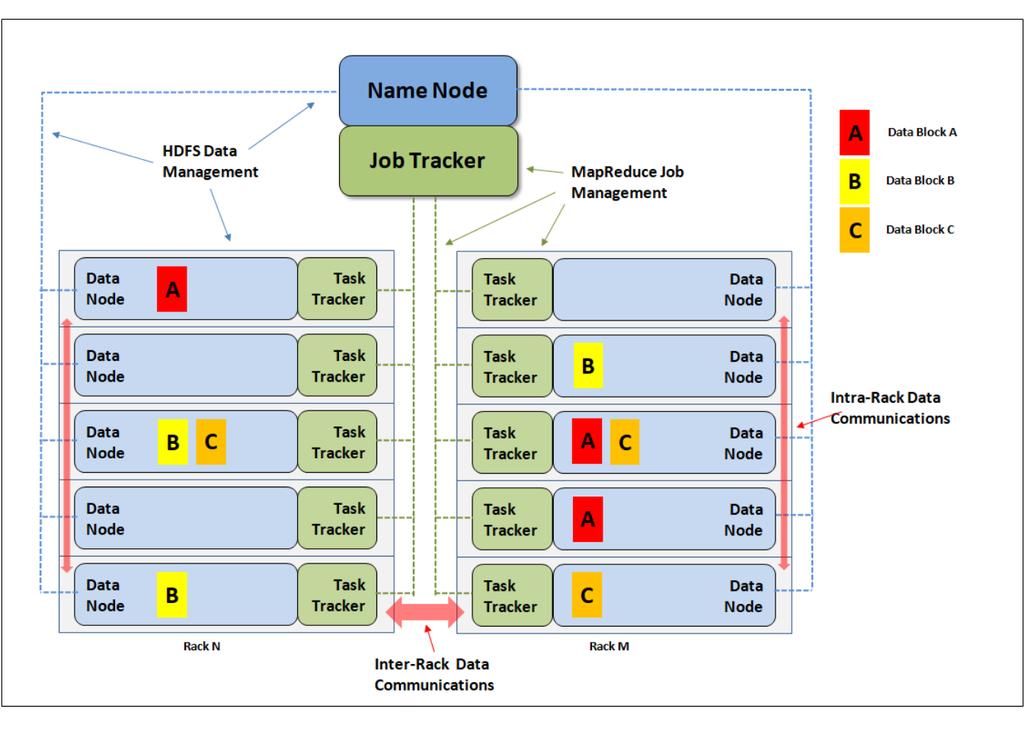

##### Fig.1 - Hadoop-HDFS-MapReduce

Important concepts for understanding HDFS are:

- Name Node - the controlling node, managing the namespace and mapping of files to blocks on the worker nodes
- Worker Nodes - the data storage nodes where the blocks of data are stored
- HDFS block size - the granularity of the HDFS file blocks on each node - typically 128MB
- HDFS redundency - how much the data is replicated over the worker nodes - typically 3 times

The Name Node manages the data nodes and the mapping of files to HDFS blocks on the data nodes. Data nodes store the data in units of HDFS blocks (default is 128MB) and keep a heartbeat link signal with the Name Node.

HDFS is designed for failure, as such data blocks are typically replicated (default of 3 times) on at least one other physically separate rack. Failure of a data node causes the name node to use the replicated blocks on the other data nodes so as to not interrupt data processing.

HDFS is not designed for random access read/write. It is designed to write once and then fast sequential reading of the entire block. Blocks are not updated, they are just overwritten.

Map-reduce, on the other-hand, is a way of processing the large amounts of data that is distributed on the HDFS cluster. The fundamental ideas of the Map-reduce paradigm are:

1. to move as much of the the processing to the data nodes as the data is too large to pass around the cluster
2. to deal with the inevitable loss of worker nodes in a coherent manner

Thus we define a task tracker(see. Fig.1), which is typically mapped 1:1 to each data node, it doesn’t have to be, but that is the recommended configuration. The Task Tracker deals with its subset of whatever task (map or reduce) is at hand. Managing the entire Map-reduce job is the Job Tracker, equivalent of the Name Node, it basically coordinates the task trackers to ensure the Map-reduce job gets done.

Both the Map-reduce and Spark data processing mechanisms, could operate over other file systems, however, for the purposes of this document, the assumption is that they are working over HDFS-Hadoop which they are both designed to do seamlessly.

### MapReduce

#### Overview

As mentioned previously, Map-reduce is the data processing mechanism designed to work with the unique challenges of data that is to large to fit on a single server. Google engineers developed Map-reduce after analysis of their large scale analytics operations revealed that as the raw data was generally structured as a collection of records which was partitioned into blocks, processing jobs could be broken down into a map phase to transform each record independently into an intermediate list of key-value pairs and a reduce phase to sort and aggregate the intermediate results by key, see fig.2.

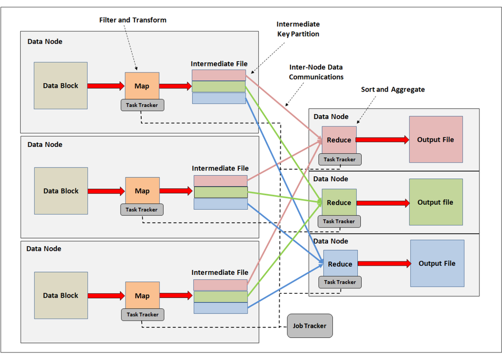

##### Fig.2 - MapReduce

#### Details

The map phase is where individual records from each data block are passed to a map function that performs some operation on the record and returns none, one or more intermediate key-value pairs as output. This type of processing was influenced by the functional programming paradigm of map with lambda functions found in Lisp and other languages. The independent element-wise map function suited big-data scenarios as it could be be done on subsections (splits or blocks) of the whole data in parallel. An added benefit of the partitioned/parallel nature of the mapping process was that it was simple to deal with worker node failure by re-processing that block only. The type of function handled by the mapper could be anything from a simple identity function to any combination of filtering and transformation of records. What is common is that each record is processed without dependence on other records. In terms of incoming record format, each record would typically be a key-value pair where the key is just an identifier and the value could be anything from a single integer, a double to an array, a string, a tree, a forest, a document, an image, a video a collection of videos etc. Similarly, the intermediate record format is a key-value pair, only being related to the input record by the particular map function.

The Reduce phase, also being influenced by functional programming paradigms, is the aggregation step, where the intermediate key-value output of each data block map function are sorted and combined by key with all other data block map outputs into one result set of result key-value pairs. The intermediate output data, which is stored on the mapper data node disks, is assigned to reducer data nodes by key partitioning, this means that the intermediate key space would be partitioned into R parts and each part assigned to a reducer, so a reducer would read only those intermediate results from each mapper data node that had it’s assigned keys. Note that in order for the reducer to perform aggregation by key, the incoming intermediate data would typically need to be sorted by the intermediate key. Each reducer would finally write the result to an output file for consumption by the client who would receive access to one output file for each reducer.

#### Process

In terms of process, the Job Tracker will take the map reduce job, communicate with the Name Node to determine the location of the data blocks and determine the Task Trackers for the map process. Essentially the data partitioning done by HDFS is the partitioning used by the Job Tracker to assign Task Trackers. The Task Tracker chosen for each data block is ideally co-located on the same data node, however it can possibly be on other nodes and worst case on other racks. The Job Tracker will also determine Task Trackers for the reduce process, the number will be determined by intermediate key partitioning. As each reducer task will have to read data from multiple data nodes with mapper output, there will always be network traffic created by the reducers reading the intermediate key-value data from the mapper data nodes. During the entire process, the Job Tracker manages the Task Tracker status, handles the location of the intermediate data and coordinates the overall job process. Fig.3 shows a high level process flow for a Map-reduce job from client request to job completion. The messages and exact details are symbolic only, the diagram is simply an illustration of what and when events occur relative to other events and who is involved.

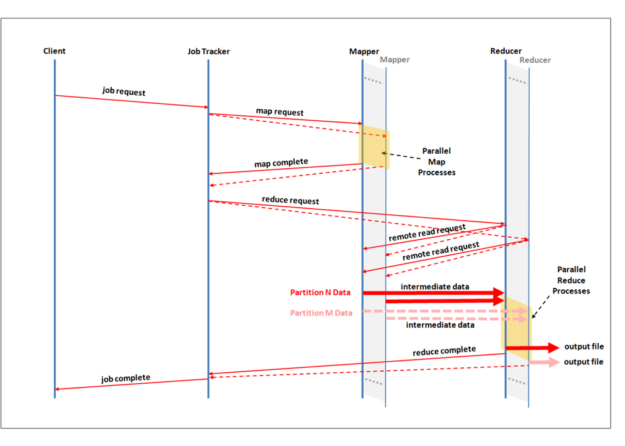

##### Fig.3 - MapReduce Highlevel Process

#### Examples

In order to better understand the concepts behind map and reduce, let’s look at some common examples. Note that the map functions are running on their assigned data block. The reduce functions are running on their assigned intermediate index partitions, see Fig.3.

One important concept to understand prior to looking at examples, as it tends to recur in the map-reduce paradigm, is the concept of a neighbour list (adjacency list) and expressing it in tall or wide format. A neighbour list is a way of representing any graph data structure. A neighbour list can be represented in two common ways that will be referred to as:

1. the tall format where each key-value pair represents an edge originating from the key node,
2. the wide format where each key-value is actually a key-list of values and it represents all the edges originating from that particular key node.

The tall format is generally better for graph storage and searching, the wide format is better for human consumption, but data can be in either format and the transformations and aggregations found in the Map-reduce process will commonly switch between the two.

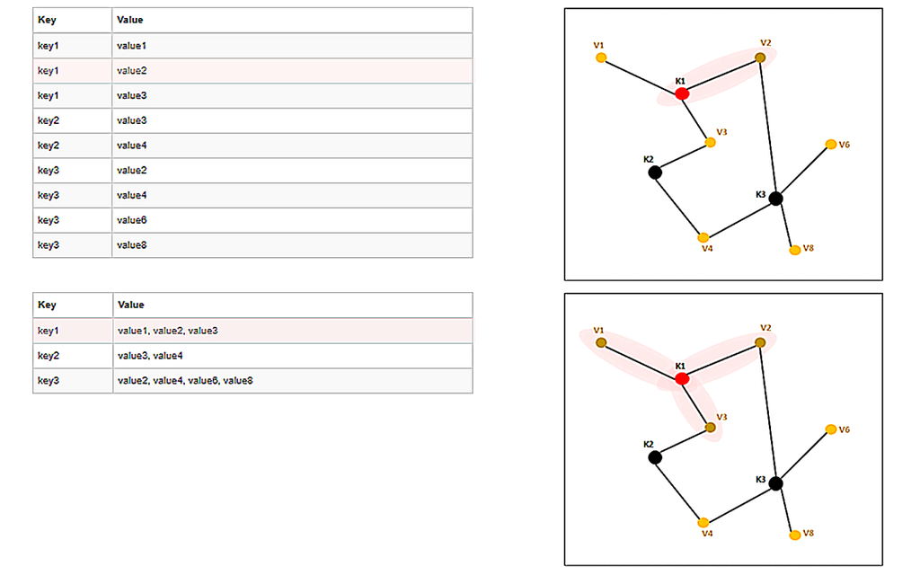

##### Tab.1 - Tall vs Wide Format Neighbour List

##### Distributed Grep

Given a dataset of text records. We want to filter only records of text containing a particular pattern. The fundamental operation is to use a grep function to select the records we want. There would be no reduce aggregation required in this case:

- Map Function => lambda x: grep “pattern” in x. which would essentially return either a copy of the input record or not depending on the grep result. In other words, this map function is essentially a filter.
- Reduce Function => Identity (transparent). In this case as the map did the job. Each reduce function simply reads it’s assigned intermediate key partition from the mapper data nodes and writes the remaining data the output file.

##### URL Access Frequency Counting

Given a dataset of URL request logs. We want to aggregate the number of requests per unique URL. The basic operations here are identifying the URL for each log entry and then summing the requests for each URL.

- Map Function => lambda x: if x is a valid URL request, get the URL. This would return the URL as the key for each record with a value of 1 for 1 request.
- Reduce Function => Each reducer will read only those intermediate records from each mapper data node with keys that fall in the reducers assigned key partition. The reducer will then sort the incoming data by key and then aggregate it summing all like URLs by value and writing to the output file the key-value pair of URL and the total sum for each unique URL.

##### Target-Source WebLink Analysis

Given a dataset of webpage URLs, where for each record, the key is the webpage URL and the value is the HTML code for the URL. We want to create a neighbor-list of linking source-URLs for each target URL. The process for this would involve extracting the all target URLs found for each source URL and returning a target-source (key-value) list found in each source URL. Then aggregating them together from tall format(1 pair per record) to wide format(1 target and multiple sources per record) to form a target,source neighbor list.

- Map Function => lambda x: get the source URL and find all target URLs in x. For each incoming record, this would return a list of target-source URL pairs.
- Reduce Function => Each reducer will read only those intermediate records from each mapper data node with keys that fall in the reducers assigned key partition. The reducer will then sort the incoming data by target URL and then aggregate each target URL down to one record with the target URL as the key and the list of all unique source URLs as the value.

NOTE: for this particular scenario, the actual neighbor list returned is a reverse neighbor list, target-source. It would have been as simple as changing the order of the output of the map function to source-target pairs to generate a forward neighbor list.

##### Word Frequency Counting

Given a dataset of documents, where each record is a key-value pair of the document name as key and the associated document contents as value. We want to count the frequency of non-trivial terms (words) for each document and output a key-value pair of the extracted URL for the key and a term vector for the value(a sorted list of frequent terms with associated counts). This process would involve crawling each document, extracting the URL and pulling out distinct non-trivial words and incrementing a counter for each word returning a term vector for each URL. Then aggregating for each URL all the term vectors into one sorted term vector.

- Map Function => lambda x: search for the URL and set as key, for each word in the document, compare to an ignore list of trivial words, if passed create or increment the counter for that word and finally return a key-value pair with the URL as key and the term vector as the value.
- Reduce Function => Each reducer will read only those intermediate records from each mapper data node with keys that fall in the reducers assigned key partition. The reducer will then sort the incoming data by URL and merge the term vectors for each distinct URL into one final term vector (summing the counts for each distinct word and sorting the final vector), only keeping the most frequent terms according to some arbitrary frequency threshold.

NOTE: this could also be implemented by the mapper returning a set of key-value pairs for each document, such that each key value pair has the URL as key and a distinct word and count pair as value, not a full term vector (i.e tall format vs wide format). The reducer in this second scenario, would then sort the incoming key-value pairs by key then value and then combine same word counts, then combine same URL words into a term vector per URL.

##### Word to Documents Indexing

Given a dataset of documents, where each record is a key-value pair of the document name as key and the associated document contents as value. We want as output a list of key-value pairs where the key is a non-trivial word and the value is the list of documents containing that particular word. This process would involve extracting the word document pairs from each document and then combining them into a wide-format word-containing document list.

- Map Function => lambda x: return all found key-value pairs of distinct non-trivial words found in the document with the word as key and the document id as value.
- Reduce Function => Each reducer will read only those intermediate records from each mapper data node with words that fall in the reducers assigned key partition. The reducer will then sort the incoming data by word and then convert to wide format with the word as the key and the list of all distinct document ids where it is found as the value.

##### Distributed Sort

Given a dataset of records, we would like to sort the records by some key found in each record. This would be achieved by first extracting the key from each record and then a multistage sorting algorithm.

- Map Function => lambda x: extract the key and value from x and return a key-value pair for each record.
- Reduce Function => Each reducer will read only those intermediate records from each mapper data node with words that fall in the reducers assigned key partition, eg. if the keys are alphabetical, one reducer may only want keys D to G. The actual partitioning function in this case is the first sorting stage as the partition assigned to each reducer would be a section of the sorted key space. Each reducer would then read those keys from each mapper data node and sort the incoming data by key before writing to it’s output file.

The resulting set of output files would have records sorted by key and each file would have a continuous subset of the sorted key space.

### Spark

#### Overview

Spark can be thought of as an improved version of Map-reduce, it was designed to overcome some of the the main issues with Map-reduce like intermediate data disk I/O, complex programming interface, inability to handle iterative processing scenarios.

Some key concepts behind Spark are:

- RDD (Resilient Distributed Dataset). The data collection object used by Spark to store data
- RDD Lineage. A process can be any number of chained/iterative RDD transformations, each one taking in an RDD and returning another RDD
- RDD Resiliency. Where any intermediate RDD can be recalculated from it’s ancestor RDDs via the lineage graph if it is lost due to node failure
- Transformations and Actions. All user defined operations in Spark are divided into two categories, Transformations which take and return RDDs and Actions which take RDDs and return real data to the driver program
- Lazy Evaluation. A chain of RDD transformations is actually not evaluated until an action is called, which demands data output to the real world, this allows for processing chain optimisation via the DAG scheduler
- DAG (Directed Acyclic Graph) scheduling, when an RDD transformation chain is forced to evaluate via an action call, it is passed to the DAG scheduler which converts the logical RDD chain into a physical series of processing stages, this can involve changing and shuffling the transformations. Thus allowing the DAG scheduler to optimise the processing chain to find a more efficient way of obtaining the same result.
- As a result of these key concepts Spark intermediate data can be kept in volatile memory allowing for great performance gains over Map-reduce. However, note that a poorly designed Spark workflow can still cause data to go to disk, thus greatly reducing any benefits from the Spark paradigm. Newer Spark constructs such as Spark dataframes and Spark Datasets are an attempt to further simplify the user programming required and pass even more process optimising scope to the DAG scheduler.
- Spark is written Scala and runs on Java. Allowing simple programming and interactivity with the Spark shell.

On a very high level, Spark is a data processing engine that sits on a resource manager. Spark also has several libraries that add functionality over the traditional map-reduce paradigm:

- Spark SQL => interactive and batch analytics
- Spark Streaming => Real-time analytics
- MLlib => Machine Learning
- Graph => Graph Processing

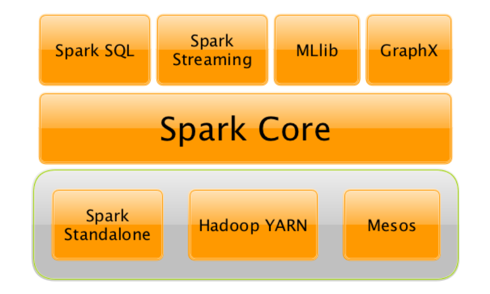

##### Fig.4 - Spark Higher Level Libraries

#### Architecture

The basic architecture of a Spark system can be divided into 3 main areas, see fig.5:

1. The Driver Program which contains the spark context, the gateway to all internal spark operations. Some key components of the context are:
   - The RDD chain, the graph of RDD transformations.
   - The DAG scheduler, this is the RDD to task optimisation engine.
   - The Task Scheduler, this takes the output of the DAG Scheduler and actually handles running the tasks on the executors of the workers as well as dealing with failures and stragglers, much like the Job Tracker in Map-reduce.
   - Resource Negotiation, interface to the cluster manager to negotiate for resources to run executors and tasks.
2. The Cluster Manager. This could be the default Spark resource manager, YARN or Mesos. Manages cluster access and resource allocation.
3. The Worker Nodes, which host the executors who run the tasks assigned by the Task Scheduler and manage data storage in memory or on disk. The executors typically persist for the entire lifetime of the Spark context, the tasks contain all the functions, objects and operations to perform for each transformation and action.

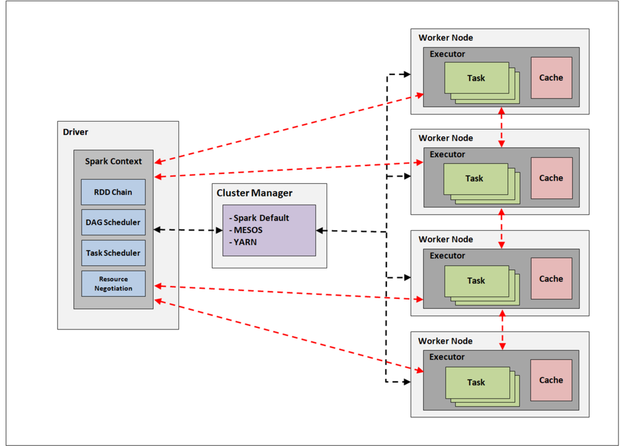

##### Fig.5 - Spark Cluster Architecture

#### RDD

The RDD (Resilient Distributed Dataset) is the logical data structure of Spark. An RDD is an immutable collection of elements that is divided into physical partitions (based on the underlying file system) and stored in a distributed way on a cluster. As such RDDs are suitable for parallel operations.

#### RDD Chaining

An RDD can initially be created from data ingested from some source. From that point any transformation of that RDD will return another RDD. Thus, based on the requirements of a job, a chain (or DAG) of RDDs will be generated, this is the RDD lineage. This lineage of RDDs allows any RDD to be recreated apon loss of a partition as it can simply be recalculated. It is also called the logical RDD execution plan.

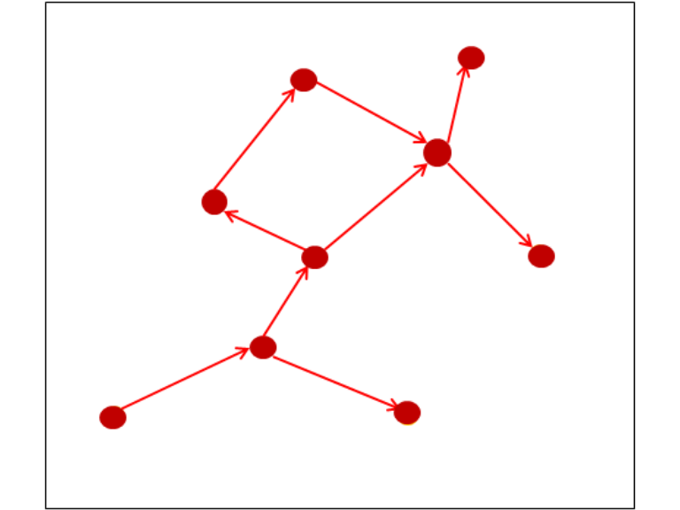

##### Fig.6 - RDD DAG/Chain

#### RDD Persistance

RDDs can be explicitly persisted in memory or on disk. In memory caching is especially beneficial in the case of iterative and interactive data flows, which sets Spark apart from traditional Map-reduce paradigms. If not persisted RDDs are ephemeral and recalculated as needed. If there are memory issues or the RDD chain is sub-optimal or even if user specified, RDDs may need to be persisted on disk.

#### Actions and Transformations

In Spark there are two main types of operations, Transformations and Actions. Transformations are when an RDD is manipulated in some way (filter, aggregatebykey, map) and the output is an RDD. Actions are when data is requested back to the real world (reduce, collect, take). An action takes in RDDs but returns real data to the driver and effectively represents the end of the RDD lineage.

It is important to classify transformations into two main groups, transformations that involve shuffling and those that do not, see Fig.7. Shuffling transformations are complex and expensive, creating processing load, memory load and network traffic. Transformations that can cause shuffling are the traditional reduce by key, but can include many others like distinct, join, sort and re-partition. In these cases we are forced to generate network traffic as we have to pull data from different physical and logical partitions around the cluster and send it to another set of physical and logical partitions, also distributed around the cluster. Straight transformations such as map and filter do not change the location of the data, see Fig.7.

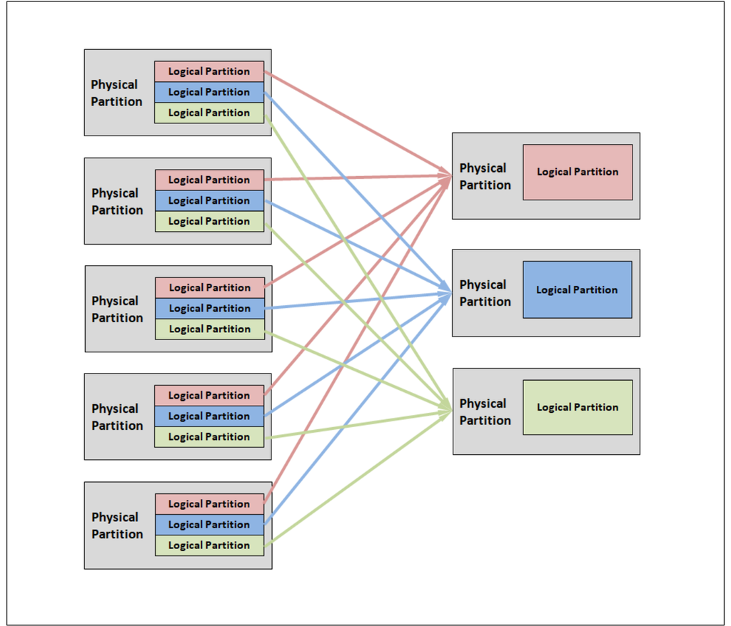

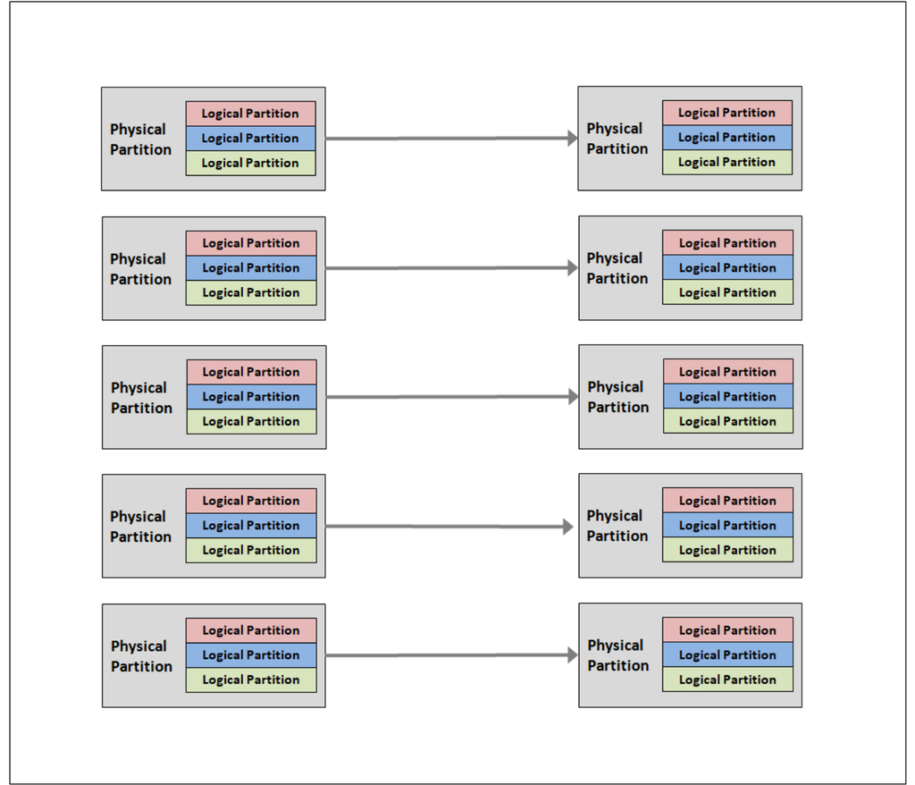

##### Fig.7 - Shuffle Transformation vs Straight Transformation

#### Lazy Evaluation

Lazy evaluation is due to Spark only evaluating an RDD DAG when an action is called. If no action is called, the RDD DAG will get longer and longer, but no calculations will take place. One of the primary reasons for this is to allow the DAG scheduler an opportunity to optimise the processing of an RDD DAG.

#### DAG Scheduler and Task Scheduler

Once an action has been called, forcing evaluation of the current RDD chain. The chain is passed to the DAG scheduler. This will convert the RDD transformations into a series of task stages (or a DAG of stages) that are optimised to run as efficiently as possible in terms of memory usage and data locality. The DAG scheduler output then goes to the Task Scheduler which will manage the running of the DAG of stages, including dealing with node failures and task stragglers by assigning new nodes to take over. One important concept to understand is the treatment of shuffling transformations vs straight transformations by the DAG scheduler, see Fig.7/8. Straight transformations can be combined and possibly moved between stages, while shuffling transformations tend to form the task DAG stage boundaries.

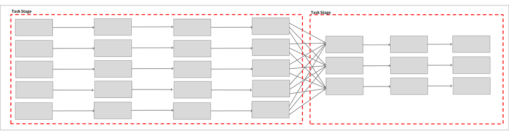

##### Fig.8 - Task Stage Grouping

#### Examples

Some simple usage examples are shown here. The code shown is using the Python API.

#### Example 1 - Text Search

Given a large logfile stored in HDFS, we want to count the logs containing “ERROR”. The Spark commands for this could be:

```python
#initially we need to create our RDD from whatever source.  Assuming here we have the initial RDD called raw_data which is an RDD of text lines.
#this is the function to search for our desired text
import re    # using re, could just use .find or even the Spark built in filter.contains
def search_term(line):
    if re.search('ERROR',line) is not None:
      return 1
    else:
      return 0
#this performs the transform to search and return 1 or 0
rdd1 = raw_data.map(search_term)
#this is the reduce term which is an action, it passes the RDD chain to the DAG scheduler for evalutaion.  The output of the reduce in this case is an addition of each RDD element (1 or 0) thus indicating the number of raw_data elements containing the desired search term.
rdd1.reduce(lambda x,y: x+y)
```

#### Example 2 - Target-Source Weblink Analysis

This is the same example from the Map-reduce case. Unlike Map-reduce, for Spark the actual commands can be shown.

Given a dataset of webpages, where for each record, the key is the webpage URL and the value is the HTML code for the URL. We want to create a neighbor-list of linking source-URLs for each target URL. The process for this would involve extracting the all target URLs found for each source URL and returning a target-source (key-value) list found in each source URL. Then aggregating them together from tall format(1 pair per record) to wide format(1 target and multiple sources per record) to form a target,source neighbor list. Here is the most obvious way to do this in Spark please read code comments for explanation:

```python
#at this point we have already got the raw_data into an RDD called raw_data, which is simply an RDD of text lines.
#this is the function for the map transformation to extract the source and target URLs from the input line.  It would not be possible to write this as a lambda function
def extract_data(line):
    data = line.split(',')
    source_url = data[0]
    data = data[1].split('href=')[1:]
    return [(x.split('"')[1],source_url) for x in data]
#this does the first transformation,this is a straight transformation, it returns many key-value tuples in the output RDD for each row in the input RDD (using .flatMap instead of .map)
rdd1 = raw_data_rdd.flatMap(extract_data)
#this does the second transformation, it is a groupbykey, so it is a full shuffle, there is another way to do it  with combinebykey that is a little more complicated to write, but may be faster for large clusters as it does some shuffle optimisation.
rdd2 = rdd1.groupByKey().mapValues(list)
#this is the action => the collect on RDD2 forces the whole RDD DAG to be sent to the DAG scheduler and evalutated and the contents of RDD2 converted to an actual python object, where we do some final sorting and removal of doubles.  NOTE: we could have run a .distinct on rdd1, but distinct has shuffle potential, so it was better to do that check last when the reduced data was already in python.
[(x[0],list(set(x[1]))) for x in sorted(rdd2.collect())]
```

##### Example 3 - Distributed Sort

Same example as in the Map-reduce section.

Given a dataset of records, we would like to sort the records by some key found in each record. This would be achieved by first extracting the key from each record and then sorting. Spark code would be as follows:

```python
#at this point we have already got the raw_data into an RDD called raw_data, which is simply an RDD of text lines.
#first we transform the raw RDD to an RDD of key-value pairs, extracting whatever feature we want to sort on for the key
def convert_to_kv(line):
    data = line.split(',')
    #do whatever you need to do
    #code not shown as it could be anything
    return (key, value)
#this applies the conversion function, uses a regular .map function this time
rdd1 = raw_data_rdd.map(convert_to_kv)
#this is the sort function, in Spark it is explicit
rdd2 = rdd1.sortByKey()
#this is the action => the collect on RDD2 forces the whole RDD DAG to be sent to the DAG scheduler and evalutated and the contents of RDD2 converted to an actual python object.
rdd2.collect()
```

#### References

Dean, J., & Ghemawat, S. (2004). MapReduce: Simplified data processing on large clusters. Google, Inc.

Zaharia, M. Introduction to MapReduce and Hadoop. UC Berkeley RAD Lab.

Zaharia, M., Chowdhury, M., Franklin, M. J., Shenker, S., & Stoica, I. (2010). Spark: Cluster Computing with Working Sets. University of California, Berkeley.

The Apache Software Foundation. (2018). Retrieved from www.spark.apache.org